# 데이터 과학자가 바라본 제7회 지방선거

정당별 광역단체장 추세

# 1 역대 지방선거 광역단체장

역대 지방선거 광역단체장에 대한 선거결과를 위키백과사전에서 확인이 가능하다.

- [대한민국 제4회 지방 선거](https://ko.wikipedia.org/wiki/대한민국_제4회_지방_선거)
- [대한민국 제5회 지방 선거](https://ko.wikipedia.org/wiki/대한민국_제5회_지방_선거)
- [대한민국 제6회 지방 선거](https://ko.wikipedia.org/wiki/대한민국_제6회_지방_선거)
- [대한민국 제7회 지방 선거 여론조사](https://ko.wikipedia.org/wiki/대한민국_제7회_지방_선거_여론_조사)

[대한민국 제7회 지방 선거 여론조사](https://ko.wikipedia.org/wiki/대한민국_제7회_지방_선거_여론_조사) 결과는 현재 시점 2018-05-30 여론조사결과를 바탕으로 제7회 지방선거 광역단체장 정당별 획득수를 추측해 본다.

# 2 선거 결과 데이터

## 2.1 [대한민국 제4회 지방 선거](https://ko.wikipedia.org/wiki/대한민국_제4회_지방_선거)

[대한민국 제4회 지방 선거](https://ko.wikipedia.org/wiki/대한민국_제4회_지방_선거) 웹사이트에서 데이터를 긁어와서 데이터프레임으로 변환시킨다.

```r
# 0. 환경설정 -----
library(tidyverse)
library(rvest)
library(slopegraph)
library(extrafont)
loadfonts()

# 1. 데이터 -----
## 1.1. 제 5 회 지방선거 결과 -----
### 데이터 가져오기
Sys.setlocale("LC_ALL", "C")

four_url <- "https://ko.wikipedia.org/wiki/대한민국_제4회_지방_선거"

sido_four_df <- read_html(four_url) %>%
    html_node(xpath='//*[@id="mw-content-text"]/div/table[2]') %>%
    html_table(fill=TRUE)

Sys.setlocale("LC_ALL", "Korean")

### 데이터 정제
sido_four_df <- sido_four_df %>%
    filter(!str_detect(지역, "투표율")) %>%
    mutate(득표율 = str_replace_all(득표율, "%", "") %>% as.numeric,
           비고 = str_extract(비고, "^[0-9가-힣].+")) %>%
    mutate(선수 = ifelse(is.na(비고), "초선", 비고)) %>%
    mutate(선수 = factor(선수, levels = c("초선", "재선", "3선"))) %>%
    rename(시도명=지역)
DT::datatable(sido_four_df)
```

## 2.2 [대한민국 제5회 지방 선거](https://ko.wikipedia.org/wiki/대한민국_제5회_지방_선거)

[대한민국 제5회 지방 선거](https://ko.wikipedia.org/wiki/대한민국_제5회_지방_선거) 웹사이트에서 데이터를 긁어와서 데이터프레임으로 변환시킨다.

```r
# 1. 데이터 -----
## 1.1. 제 5 회 지방선거 결과 -----
### 데이터 가져오기
Sys.setlocale("LC_ALL", "C")

five_url <- "https://ko.wikipedia.org/wiki/대한민국_제5회_지방_선거"

sido_five_df <- read_html(five_url) %>%
    html_node(xpath='//*[@id="mw-content-text"]/div/table[4]') %>%
    html_table(fill=TRUE)

Sys.setlocale("LC_ALL", "Korean")

### 데이터 정제
sido_five_df <- sido_five_df %>%
    filter(!str_detect(지역, "투표율")) %>%
    mutate(득표수 = str_replace_all(득표수, ",", "") %>% as.integer,
              득표율 = str_replace_all(득표율, "%", "") %>% as.numeric) %>%
    mutate(선수 = ifelse(비고 == "", "초선", 비고)) %>%
    mutate(선수 = factor(선수, levels = c("초선", "재선", "3선"))) %>%
    rename(시도명=지역)

DT::datatable(sido_five_df)
```

## 2.3 [대한민국 제6회 지방 선거](https://ko.wikipedia.org/wiki/대한민국_제6회_지방_선거)

[대한민국 제6회 지방 선거](https://ko.wikipedia.org/wiki/대한민국_제6회_지방_선거) 웹사이트에서 데이터를 긁어와서 데이터프레임으로 변환시킨다.

```r
# 1. 데이터 -----
## 1.1. 제 6 회 지방선거 결과 -----
### 데이터 가져오기
Sys.setlocale("LC_ALL", "C")

six_url <- "https://ko.wikipedia.org/wiki/대한민국_제6회_지방_선거"

sido_six_df <- read_html(six_url) %>%
    html_node(xpath='//*[@id="mw-content-text"]/div/table[4]') %>%
    html_table(fill=TRUE)

Sys.setlocale("LC_ALL", "Korean")

### 데이터 정제
sido_six_df <- sido_six_df %>%
    filter(!str_detect(지역, "투표율")) %>%
    mutate(득표수 = str_replace_all(득표수, ",", "") %>% as.integer,
              득표율 = str_replace_all(득표율, "%", "") %>% as.numeric) %>%
    mutate(선수 = ifelse(비고 == "", "초선", 비고)) %>%
    mutate(선수 = factor(선수, levels = c("초선", "재선", "3선"))) %>%
    rename(시도명=지역)

DT::datatable(sido_six_df)
```

## 2.4 [대한민국 제7회 지방 선거 여론조사](https://ko.wikipedia.org/wiki/대한민국_제7회_지방_선거_여론_조사)

제7회 지방선거 여론조사는 [데이터 과학자가 바라본 제7회 지방선거 - 광역단체장 판세(2018-05-22)](http://statkclee.github.io/politics/sido-status-2018-05-22.html#22_%EC%A0%9C7%ED%9A%8C_%EC%A7%80%EB%B0%A9%EC%84%A0%EA%B1%B0_%EC%97%AC%EB%A1%A0%EC%A1%B0%EC%82%AC) 웹페이지를 참조한다.

# 3 데이터 정제

제4회부터 제6회까지는 역사적 사실로 각 정당별 광역단체장 선출데이터에 근거하고, 제7회 지방선거 광역단체장은 2018-05-30 기준 여론조사 기준으로 광역단체장을 추정한다. 그리고, 정당명칭이 제4회부터 현재까지 지속적으로 변경이 되어 일관성을 위해서 다음과 같이 정당명을 정리한다.

- 제4회 지방선거
  - 한나라당 → 자유한국당
  - 열린우리당, 민주당 → 더불어민주당
- 제5회 지방선거
  - 한나라당 → 자유한국당
  - 민주당 → 더불어민주당
- 제6회 지방선거
  - 새누리당 → 자유한국당
  - 새정치민주연합 → 더불어민주당

```r
## 1.1. 제4회
sido_four_df <- read_rds("data/sido_four_df.rds") %>%
    count(소속정당) %>%
    rename(정당=소속정당)

## 1.1. 제5회
sido_five_df <- read_rds("data/sido_five_df.rds") %>%
    count(정당)

## 1.2. 제6회
sido_six_df <- read_rds("data/sido_six_df.rds") %>%
    count(정당)

## 1.3. 제7회 여론조사
sido_seven_df <- read_rds("data/sido_survey_df.rds")

names(sido_seven_df)  <- c("조사 의뢰", "조사 기관", "응답 인원", "더불어민주당", "자유한국당",
                           "바른미래당", "정의당", "기타·무응답", "참고", "조사일", "시도명",
                           "민주평화당", "무소속")

sido_seven_now_df <- sido_seven_df %>%
    mutate(무소속 = str_replace_all(무소속, "%", "") %>% as.numeric,
              민주평화당 = str_replace_all(민주평화당, "%", "") %>% as.numeric) %>%
    group_by(시도명) %>%
    filter(조사일 == max(조사일)) %>%
    select(시도명, contains("당"), contains("무소속")) %>%
    ungroup()

current_df <- sido_seven_now_df %>%
    gather(정당, 지지율, -시도명) %>%
    mutate(지지율 = as.numeric(지지율)) %>%
    group_by(시도명) %>%
    summarise(지지율 = max(지지율, na.rm=TRUE))

sido_current_df <- sido_seven_now_df %>%
    gather(정당, 지지율, -시도명) %>%
    mutate(지지율 = as.numeric(지지율)) %>%
    inner_join(current_df)

sido_seven_viz_df <- sido_current_df %>%
    count(정당)

## 1.3. 데이터 병합 -----
sido_four_viz_df <- sido_four_df %>%
    mutate(정당 = case_when(str_detect(정당, "한나라당") ~ "자유한국당",
                          str_detect(정당, "열린우리당|민주당") ~ "더불어민주당",
                          TRUE ~ 정당)) %>%
    group_by(정당) %>%
    summarise(제4회 = sum(n))


sido_five_viz_df <- sido_five_df %>%
    mutate(정당 = case_when(str_detect(정당, "한나라당") ~ "자유한국당",
                          str_detect(정당, "민주당") ~ "더불어민주당",
                          TRUE ~ 정당)) %>%
    rename(제5회 = n)

sido_six_viz_df <- sido_six_df %>%
    mutate(정당 = case_when(str_detect(정당, "새누리당") ~ "자유한국당",
                            str_detect(정당, "새정치민주연합") ~ "더불어민주당")) %>%
    rename(제6회 = n)

sido_seven_viz_df <- sido_seven_viz_df %>%
    rename(`제7회(예상)` = n)

sido_viz_df <- full_join(sido_four_viz_df, sido_five_viz_df) %>%
    full_join(sido_six_viz_df) %>%
    full_join(sido_seven_viz_df) %>%
    as.data.frame() %>%
    column_to_rownames(var="정당")

DT::datatable(sido_viz_df)
```

|  | 제4회 | 제5회 | 제6회 | 제7회(예상) |
| --- | --- | --- | --- | --- |
| 더불어민주당 | 3 | 7 | 9 | 12 |
| 무소속 | 1 | 2 |  | 1 |
| 자유한국당 | 12 | 6 | 8 | 2 |
| 자유선진당 |  | 1 |  |  |

# 4 시각화

그래프 문법(grammar of graphics)이 지원되는 slopegraph를 활용하여 각 정당을 대표한 색상을 반영하여 경사그래프로 각정당별 역대 선거를 시각화한다.

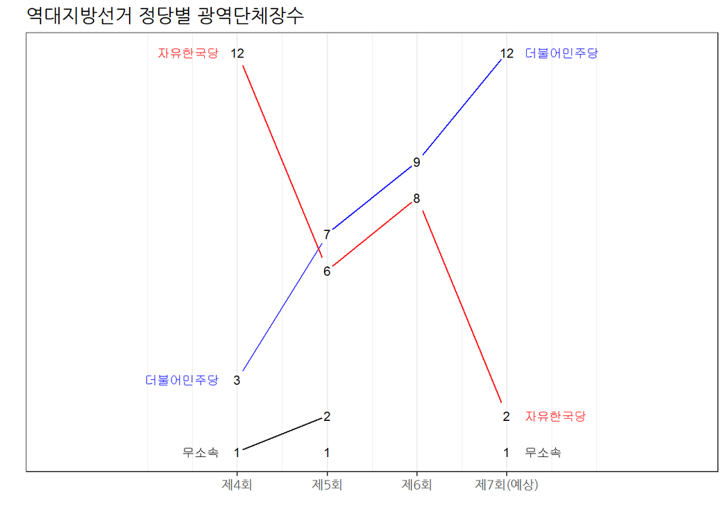

```r
# 3. 시각화 -----

cols <- `[<-`(rep("black", 4), 1, "blue")
cols <- `[<-`(cols, 3, "red")

ggslopegraph(sido_viz_df, offset.x = 0.06, yrev = FALSE,
             col.lines = cols, col.lab = cols,
             main = '역대지방선거 정당별 광역단체장수') +
    theme_bw(base_family="NanumGothic")
```

# 5 공간정보 시각화

## 5.1 공간정보 정적 그래프

각정당별 광역단체장 당선 현황을 공간정보에 표기해보자. 이를 위해서 지리정보 코드표(`spatial_tbl`)를 작성하고 `magick` 팩키지 `.gif` 애니메이션 기능을 동원한다.

```r
# 0. 환경설정 -----
library(tidyverse)
library(rvest)
library(glue)
library(sf)
library(gridExtra)
library(magick)

# 1. 데이터 -----
# 1.0. 지도정보 룩업표
spatial_tbl <- tribble(
    ~"CTPRVN_CD", ~"CTP_KOR_NM", ~"시도명",
    11,  "서울특별시",  "서울특별시장",
    26,  "부산광역시",  "부산광역시장",
    27,  "대구광역시",  "대구광역시장",
    28,  "인천광역시",  "인천광역시장",
    29,  "광주광역시",  "광주광역시장",
    30,  "대전광역시",  "대전광역시장",
    31,  "울산광역시",   "울산광역시장",
    36,  "세종특별자치시", "세종특별자치시장",
    41,  "경기도",         "경기도지사",
    42,  "강원도",         "강원도지사",
    43,  "충청북도",      "충청북도지사",
    44,  "충청남도",      "충청남도지사",
    45,  "전라북도",      "전라북도지사",
    46,  "전라남도",      "전라남도지사",
    47,  "경상북도",      "경상북도지사",
    48,  "경상남도",      "경상남도지사",
    50,  "제주특별자치도", "제주특별자치도지사"
)

## 1.1. 제4회 지방선거
sido_four_df <- read_rds("data/sido_four_df.rds")

sido_four_df <- left_join(sido_four_df, spatial_tbl, by=c("시도명" = "CTP_KOR_NM")) %>%
    mutate(CTPRVN_CD = factor(CTPRVN_CD)) %>%
    rename(CTP_KOR_NM=시도명,
           시도명=시도명.y)

## 1.2. 제5회 지방선거
sido_five_df <- read_rds("data/sido_five_df.rds")
sido_five_df <- left_join(sido_five_df, spatial_tbl, by=c("시도명" = "CTP_KOR_NM")) %>%
    mutate(CTPRVN_CD = factor(CTPRVN_CD)) %>%
    rename(CTP_KOR_NM=시도명,
           시도명=시도명.y)

## 1.3. 제6회 지방선거
sido_six_df <- read_rds("data/sido_six_df.rds")
sido_six_df <- left_join(sido_six_df, spatial_tbl) %>%
    mutate(CTPRVN_CD = factor(CTPRVN_CD))

## 1.4. 제7회 여론조사
sido_seven_df <- read_rds("data/sido_survey_df.rds")

names(sido_seven_df)  <- c("조사 의뢰", "조사 기관", "응답 인원", "더불어민주당", "자유한국당",
                           "바른미래당", "정의당", "기타·무응답", "참고", "조사일", "시도명",
                           "민주평화당", "무소속")

sido_seven_now_df <- sido_seven_df %>%
    mutate(무소속 = str_replace_all(무소속, "%", "") %>% as.numeric,
              민주평화당 = str_replace_all(민주평화당, "%", "") %>% as.numeric) %>%
    group_by(시도명) %>%
    filter(조사일 == max(조사일)) %>%
    select(시도명, contains("당"), contains("무소속")) %>%
    ungroup()

current_df <- sido_seven_now_df %>%
    gather(정당, 지지율, -시도명) %>%
    mutate(지지율 = as.numeric(지지율)) %>%
    group_by(시도명) %>%
    summarise(지지율 = max(지지율, na.rm=TRUE))

sido_current_df <- sido_seven_now_df %>%
    gather(정당, 지지율, -시도명) %>%
    mutate(지지율 = as.numeric(지지율)) %>%
    inner_join(current_df)

## 1.3. 지방선거 지도 -----

## 1.2. shp 파일 불러오기 --------
sido_shp <- st_read("data/shapefile_sido/TL_SCCO_CTPRVN.shp")
```

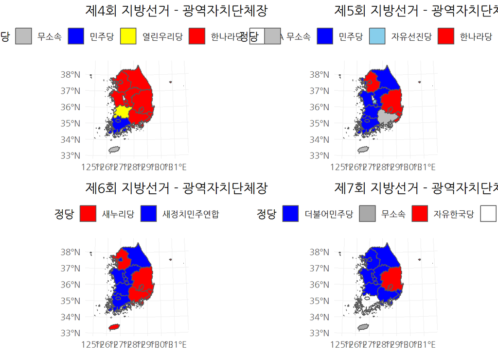

```r
# sido_shp <- st_read("data/TL_SCCO_CTPRVN.shp")
sido_shp$CTP_KOR_NM <- iconv(sido_shp$CTP_KOR_NM, from = "CP949", to = "UTF-8", sub = NA, mark = TRUE, toRaw = FALSE)
sido_simp_shp <- st_simplify(sido_shp, dTolerance = 100)

# 2. 시각화 -----
## 2.1. 제4회 지방선거
sido_four_shp <- left_join(sido_simp_shp, sido_four_df)

sido_four_g <- sido_four_shp %>% ggplot(aes(fill=sido_four_shp$소속정당)) +
    geom_sf() +
    theme_minimal(base_family="NanumGothic") +
    labs(title="제4회 지방선거 - 광역자치단체장") +
    scale_fill_manual(values =c("gray", "blue", "yellow", "red", "white")) +
    theme(legend.position = "right") +
    labs(fill="정당") +
    theme(legend.position = "top")

ggsave("data/sido_four_g.png")

## 2.2. 제5회 지방선거
sido_five_shp <- left_join(sido_simp_shp, sido_five_df)

sido_five_g <- sido_five_shp %>% ggplot(aes(fill=sido_five_shp$정당)) +
    geom_sf() +
    theme_minimal(base_family="NanumGothic") +
    labs(title="제5회 지방선거 - 광역자치단체장") +
    scale_fill_manual(values =c("gray", "blue", "skyblue", "red", "white")) +
    theme(legend.position = "right") +
    labs(fill="정당") +
    theme(legend.position = "top")

ggsave("data/sido_five_g.png")

## 2.3. 제6회 지방선거
sido_six_shp <- left_join(sido_simp_shp, sido_six_df)

sido_six_g <- sido_six_shp %>% ggplot(aes(fill=sido_six_shp$정당)) +
    geom_sf() +
    theme_minimal(base_family="NanumGothic") +
    labs(title="제6회 지방선거 - 광역자치단체장") +
    theme(legend.position = "right") +
    scale_fill_manual(values =c("red", "blue")) +
    labs(fill="정당") +
    theme(legend.position = "top")

ggsave("data/sido_six_g.png")

## 2.4. 제7회 지방선거
sido_current_df <- left_join(sido_current_df, spatial_tbl) %>%
    mutate(CTPRVN_CD = factor(CTPRVN_CD))

sido_seven_shp <- left_join(sido_simp_shp, sido_current_df)

sido_seven_g <- sido_seven_shp %>% ggplot(aes(fill=sido_seven_shp$정당)) +
    geom_sf() +
    theme_minimal(base_family="NanumGothic") +
    labs(title="제7회 지방선거 - 광역자치단체장") +
    theme(legend.position = "right") +
    scale_fill_manual(values =c("blue", "darkgray", "red")) +
    labs(fill="정당") +
    theme(legend.position = "top")

ggsave("data/sido_seven_g.png")

## 2.5. 제4회 ~ 제7회 지방선거 비교

grid.arrange(sido_four_g, sido_five_g, sido_six_g, sido_seven_g, nrow=2)
```

## 5.2 공간정보 동적 애니메이션

```
  format width height colorspace matte filesize density
1    gif  2100   1499       sRGB FALSE        0 118x118
2    gif  2100   1499       sRGB FALSE        0 118x118
3    gif  2100   1499       sRGB FALSE        0 118x118
4    gif  2100   1499       sRGB FALSE        0 118x118
```

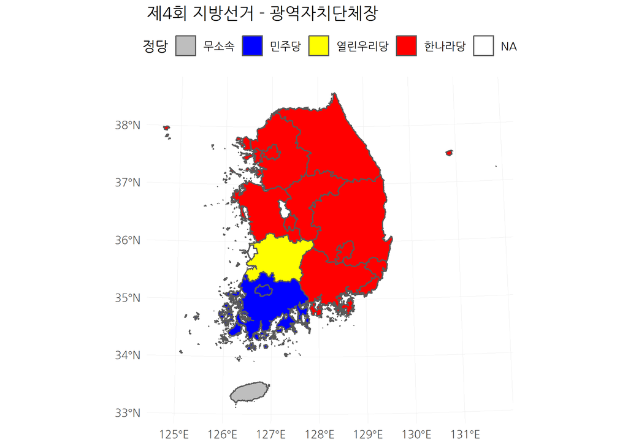

```r
# 3. 애니메이션 -----

sido_four_img <- image_read("data/sido_four_g.png")
sido_five_img <- image_read("data/sido_five_g.png")
sido_six_img <- image_read("data/sido_six_g.png")
sido_seven_img <- image_read("data/sido_seven_g.png")

sido_gif <- image_animate(c(sido_four_img, sido_five_img, sido_six_img, sido_seven_img), fps = 0.5, dispose = "previous")

print(sido_gif)
```

```r
image_write(sido_gif, "data/sido.gif")
```